# Narrated Capstone Code

Chris Leisner

June 17, 2017

```r
library(dplyr)
```

```r
library(ggplot2)
#install.packages(vcd)
#library(vcd)
```

Read in consumer complaint data from [here](https://catalog.data.gov/dataset/consumer-complaint-database#topic=consumer_navigation)

```r
setwd("C:/Users/Owner/Documents")

consumer_complaints <- read.csv("Consumer_Complaints.csv", stringsAsFactors = FALSE)
head(consumer_complaints)
```

```
##   Date.received          Product                           Sub.product
## 1    03/21/2017 Credit reporting
## 2    04/19/2017  Debt collection Other (i.e. phone, health club, etc.)
## 3    04/19/2017      Credit card
## 4    04/14/2017         Mortgage                        Other mortgage
## 5    04/19/2017      Credit card
## 6    05/18/2016         Mortgage                        Other mortgage
##                                      Issue
## 1   Incorrect information on credit report
## 2          Disclosure verification of debt
## 3                                    Other
## 4 Loan modification,collection,foreclosure
## 5                     Credit determination
## 6 Loan modification,collection,foreclosure
##                                Sub.issue Consumer.complaint.narrative
```

[output cut: 41 more lines]

```r
str(consumer_complaints)
```

```
## 'data.frame':    793263 obs. of  18 variables:
##  $ Date.received               : chr  "03/21/2017" "04/19/2017" "04/19/2017" "04/14/2017" ...
##  $ Product                     : chr  "Credit reporting" "Debt collection" "Credit card" "Mortgage" ...
##  $ Sub.product                 : chr  "" "Other (i.e. phone, health club, etc.)" "" "Other mortgage" ...
##  $ Issue                       : chr  "Incorrect information on credit report" "Disclosure verification of debt" "Other" "Loan modification,collection,foreclosure" ...
##  $ Sub.issue                   : chr  "Information is not mine" "Not disclosed as an attempt to collect" "" "" ...
##  $ Consumer.complaint.narrative: chr  "" "" "" "" ...
##  $ Company.public.response     : chr  "Company has responded to the consumer and the CFPB and chooses not to provide a public response" "" "Company has responded to the consumer and the CFPB and chooses not to provide a public response" "Company believes it acted appropriately as authorized by co…
##  $ Company                     : chr  "EXPERIAN DELAWARE GP" "Security Credit Services, LLC" "CITIBANK, N.A." "Shellpoint Partners, LLC" ...
##  $ State                       : chr  "TX" "IL" "IL" "CA" ...
##  $ ZIP.code                    : chr  "77075" "60643" "62025" "90305" ...
##  $ Tags                        : chr  "Older American" "" "" "" ...
##  $ Consumer.consent.provided.  : chr  "N/A" "" "N/A" "N/A" ...
##  $ Submitted.via               : chr  "Phone" "Web" "Referral" "Referral" ...
##  $ Date.sent.to.company        : chr  "03/21/2017" "04/20/2017" "04/20/2017" "04/14/2017" ...
##  $ Company.response.to.consumer: chr  "Closed with non-monetary relief" "Closed with explanation" "Closed with explanation" "Closed with explanation" ...
##  $ Timely.response.            : chr  "Yes" "Yes" "Yes" "Yes" ...
##  $ Consumer.disputed.          : chr  "No" "No" "No" "No" ...
##  $ Complaint.ID                : int  2397100 2441777 2441830 2436165 2441726 1931957 2393048 2216206 2436894 2444452 ...
```

The most recent date in the consumer complaints dataset is 2017-06-14 Use Date.received to get year and quarter of complaint

```r
consumer_complaints$quarterYear <- paste(quarters(as.Date(consumer_complaints$Date.received,format="%m/%d/%Y")),
                                    substr(consumer_complaints$Date.received,
                                    nchar(consumer_complaints$Date.received)-3,                                                           nchar(consumer_complaints$Date.received)), sep=" ")
```

Remove records from second quarter of 2017 since this quarter isn’t finished yet

```r
consumer_complaints  <-  consumer_complaints[consumer_complaints$quarterYear != "Q2 2017", ]
```

Find frequencies of products that got complaints so that we known which products to prioritize in our investigation

```r
(Product_freq  <-  sort(table(consumer_complaints$Product)))
```

```
##
##        Virtual currency Other financial service            Prepaid card
##                      17                    1019                    3736
##         Money transfers             Payday loan           Consumer Loan
##                    5264                    5430                   30927
##            Student loan Bank account or service             Credit card
##                   31367                   84971                   87864
##        Credit reporting         Debt collection                Mortgage
##                  136672                  142752                  225023
```

```r
write.csv(Product_freq,file = "Product_freq.csv")
```

We will first focus on the product “Mortgage” since it has the most complaints. After that I can try :

*Debt collection

*Credit reporting

*Credit card

*Bank account or service

*Consumer Loan

*Student loan

*Consumer loan

Count the number of mortgage-related consumer complaints by counting up the number of distinct mortgage complaint ids per bank. Note that this method will only capture NONZERO complaint counts, because if there are no complaints then there will be no complaint ids.

```r
consumer_complaints_mortgage  <-  consumer_complaints %>%
  filter(Product == "Mortgage")

consumer_complaint_counts_mortgage  <-  consumer_complaints_mortgage %>%
  group_by(Company, quarterYear) %>%
  summarise(complaintCount = n_distinct(Complaint.ID))

quarterCounts  <-  consumer_complaint_counts_mortgage %>%
  group_by(Company) %>%
  summarise(numquarters = n_distinct(quarterYear))
summary(quarterCounts)
```

```
##    Company           numquarters
##  Length:1243        Min.   : 1.000
##  Class :character   1st Qu.: 1.000
##  Mode  :character   Median : 2.000
##                     Mean   : 5.342
##                     3rd Qu.: 7.000
##                     Max.   :22.000
```

There are 225023 rows in the mortage complaint data

There are 6640 rows in the mortgage complaint count data

Number of quarters per bank ranges from 1 to 22, which shows that many banks have quarters with no mortgage-related complaints. For some banks and quarters, there are zero complaints. But these bank/quarter combinations are missing from the data. We have to put in the zero complaint counts ourselves.This is done below.

```r
bankNames <- unique(consumer_complaints_mortgage$Company)
quarterYears <- sort(unique(consumer_complaints_mortgage$quarterYear))

left_set <- data.frame(Company=character(), quarterYear=character())
for (Company in bankNames) {
  for (quarterYear in quarterYears) {
    newrow <- data.frame(Company = c(Company),
                        quarterYear=c(quarterYear),stringsAsFactors = FALSE)
    left_set <- rbind(left_set, newrow)
  }
}

quarterCounts  <-  left_set %>%
  group_by(Company) %>%
  summarise(numquarters = n_distinct(quarterYear))
summary(quarterCounts)
```

```
##    Company           numquarters
##  Length:1243        Min.   :22
##  Class :character   1st Qu.:22
##  Mode  :character   Median :22
##                     Mean   :22
##                     3rd Qu.:22
##                     Max.   :22
```

There are 27346 rows in left_set

```r
consumer_complaint_counts_mortgage2 <-
  left_join(left_set, consumer_complaint_counts_mortgage, by = c("Company", "quarterYear"))
```

Replace the missing complaint counts in consumer_complaint_counts_mortgage2 with 0

```r
consumer_complaint_counts_mortgage2$complaintCount<-
   ifelse(is.na(consumer_complaint_counts_mortgage2$complaintCount),0,
                consumer_complaint_counts_mortgage2$complaintCount)

quarterCounts <- consumer_complaint_counts_mortgage2 %>%
  group_by(Company) %>%
  summarise(numquarters=n_distinct(quarterYear))

summary(quarterCounts)
```

```
##    Company           numquarters
##  Length:1243        Min.   :22
##  Class :character   1st Qu.:22
##  Mode  :character   Median :22
##                     Mean   :22
##                     3rd Qu.:22
##                     Max.   :22
```

```r
summary(consumer_complaint_counts_mortgage2$complaintCount)
```

```
##     Min.  1st Qu.   Median     Mean  3rd Qu.     Max.
##    0.000    0.000    0.000    8.229    0.000 4942.000
```

There are a lot of zero complaint counts, but that’s because there are a lot of small banks

Next read in the [equity capital](http://www.usbanklocations.com/bank-rank/total-equity-capital.html?d=2016-09-30) information for the banks. The purpose is to assign a size to the banks so that we can scale their complaint counts accordingly

```r
Ranked_Banks_12_31_11 <-   read.csv('Ranked Banks 12-31-11.csv', stringsAsFactors = FALSE)
Ranked_Banks_3_31_12 <- read.csv('Ranked Banks 3-31-12.csv', stringsAsFactors = FALSE)
Ranked_Banks_6_30_12 <- read.csv('Ranked Banks 6-30-12.csv', stringsAsFactors = FALSE)
Ranked_Banks_9_30_12 <- read.csv('Ranked Banks 9-30-12.csv', stringsAsFactors = FALSE)
Ranked_Banks_12_31_12 <- read.csv('Ranked Banks 12-31-12.csv', stringsAsFactors = FALSE)
Ranked_Banks_3_31_13 <- read.csv('Ranked Banks 3-31-13.csv', stringsAsFactors = FALSE)
Ranked_Banks_6_30_13 <- read.csv('Ranked Banks 6-30-13.csv', stringsAsFactors = FALSE)
Ranked_Banks_9_30_13 <- read.csv('Ranked Banks 9-30-13.csv', stringsAsFactors = FALSE)
Ranked_Banks_12_31_13 <- read.csv('Ranked Banks 12-31-13.csv', stringsAsFactors = FALSE)
Ranked_Banks_3_31_14 <- read.csv('Ranked Banks 3-31-14.csv', stringsAsFactors = FALSE)
Ranked_Banks_6_30_14 <- read.csv('Ranked Banks 6-30-14.csv', stringsAsFactors = FALSE)
Ranked_Banks_9_30_14 <- read.csv('Ranked Banks 9-30-14.csv', stringsAsFactors = FALSE)
Ranked_Banks_12_31_14 <- read.csv('Ranked Banks 12-31-14.csv', stringsAsFactors = FALSE)
Ranked_Banks_3_31_15 <- read.csv('Ranked Banks 3-31-15.csv', stringsAsFactors = FALSE)
Ranked_Banks_6_30_15 <- read.csv('Ranked Banks 6-30-15.csv', stringsAsFactors = FALSE)
Ranked_Banks_9_30_15 <- read.csv('Ranked Banks 9-30-15.csv', stringsAsFactors = FALSE)
Ranked_Banks_12_31_15 <- read.csv('Ranked Banks 12-31-15.csv', stringsAsFactors = FALSE)
Ranked_Banks_3_31_16 <- read.csv('Ranked Banks 3-31-16.csv', stringsAsFactors = FALSE)
Ranked_Banks_6_30_16 <- read.csv('Ranked Banks 6-30-16.csv', stringsAsFactors = FALSE)
Ranked_Banks_9_30_16 <- read.csv('Ranked Banks 9-30-16.csv', stringsAsFactors = FALSE)
Ranked_Banks_12_31_16 <- read.csv('Ranked Banks 12-31-16.csv', stringsAsFactors = FALSE)
Ranked_Banks_3_31_17 <- read.csv('Ranked Banks 3-31-17.csv', stringsAsFactors = FALSE)
```

Stack the ranked banks into one set

```r
all_ranked_banks  <-  rbind(Ranked_Banks_12_31_11,
                          Ranked_Banks_3_31_12,
                          Ranked_Banks_6_30_12,
                          Ranked_Banks_9_30_12,
                          Ranked_Banks_12_31_12,
                          Ranked_Banks_3_31_13,
                          Ranked_Banks_6_30_13,
                          Ranked_Banks_9_30_13,
                          Ranked_Banks_12_31_13,
                          Ranked_Banks_3_31_14,
                          Ranked_Banks_6_30_14,
                          Ranked_Banks_9_30_14,
                          Ranked_Banks_12_31_14,
                          Ranked_Banks_3_31_15,
                          Ranked_Banks_6_30_15,
                          Ranked_Banks_9_30_15,
                          Ranked_Banks_12_31_15,
                          Ranked_Banks_3_31_16,
                          Ranked_Banks_6_30_16,
                          Ranked_Banks_9_30_16,
                          Ranked_Banks_12_31_16,
                          Ranked_Banks_3_31_17)
```

Get year and quarter from the dates

```r
all_ranked_banks$quarterYear <- paste(quarters(as.Date(all_ranked_banks$Date, format="%m/%d/%Y")),
                                    substr(all_ranked_banks$Date, nchar(all_ranked_banks$Date)-3,
                                    nchar(all_ranked_banks$Date)), sep=" ")

all_ranked_banks <- subset(all_ranked_banks, select = -Date)
```

See which quarters are in all_ranked_banks

```r
sort(unique(all_ranked_banks$quarterYear))
```

```
##  [1] "Q1 2012" "Q1 2013" "Q1 2014" "Q1 2015" "Q1 2016" "Q1 2017" "Q2 2012"
##  [8] "Q2 2013" "Q2 2014" "Q2 2015" "Q2 2016" "Q3 2012" "Q3 2013" "Q3 2014"
## [15] "Q3 2015" "Q3 2016" "Q4 2011" "Q4 2012" "Q4 2013" "Q4 2014" "Q4 2015"
## [22] "Q4 2016"
```

all_ranked_banks has 145667 observations

```r
write.csv(all_ranked_banks, file = "banks_ranked_by_equity_capital.csv")
```

The maximum rank in all_ranked_banks is 7366

Now find and eliminate the banks that have more than one rank within any quarter

```r
Ranked_banks_with_numranks <- all_ranked_banks %>%
  group_by(Bank.Name, quarterYear) %>%
  summarise(rank_count=n_distinct(Rank))

summary(Ranked_banks_with_numranks$rank_count)
```

```
##    Min. 1st Qu.  Median    Mean 3rd Qu.    Max.
##    1.00    1.00    1.00    1.17    1.00   65.00
```

```r
nrow(Ranked_banks_with_numranks)
```

```
## [1] 124445
```

```r
(rank_distr <- Ranked_banks_with_numranks %>%
  group_by(rank_count) %>%
  summarise(freq = n_distinct(Bank.Name,quarterYear)))
```

```
## # A tibble: 45 × 2
##    rank_count   freq
##         <int>  <int>
## 1           1 116868
## 2           2   4389
## 3           3   1237
## 4           4    613
## 5           5    289
## 6           6    201
## 7           7    238
## 8           8    131
## 9           9     46
## 10         10     79
## # ... with 35 more rows
```

```r
RankedBanksWithMaxRanksPerQtr <-
    Ranked_banks_with_numranks %>%
    group_by(Bank.Name) %>%
    summarise(maxNumRanks = max(rank_count))

summary(RankedBanksWithMaxRanksPerQtr$maxNumRanks)
```

```
##    Min. 1st Qu.  Median    Mean 3rd Qu.    Max.
##   1.000   1.000   1.000   1.173   1.000  65.000
```

```r
(max_num_ranks_distr <- RankedBanksWithMaxRanksPerQtr %>%
  group_by(maxNumRanks) %>%
  summarise(freq = n_distinct(Bank.Name)))
```

```
## # A tibble: 24 × 2
##    maxNumRanks  freq
##          <int> <int>
## 1            1  6346
## 2            2   247
## 3            3    66
## 4            4    31
## 5            5    17
## 6            6    10
## 7            7    12
## 8            8     9
## 9            9     3
## 10          10     4
## # ... with 14 more rows
```

93.8202247 % of the banks have one rank in every quarter

```r
RankedBanksWith1RankPerQtr <-
  RankedBanksWithMaxRanksPerQtr[RankedBanksWithMaxRanksPerQtr$maxNumRanks==1,]
```

There are 6346 banks with one rank per quarter

```r
str(RankedBanksWith1RankPerQtr)
```

```
## Classes 'tbl_df', 'tbl' and 'data.frame':    6346 obs. of  2 variables:
##  $ Bank.Name  : chr  "1880 Bank" "1919 Investment Counsel & Trust Company" "1919 INVESTMENT COUNSEL & TRUST COMPANY" "1st Advantage Bank" ...
##  $ maxNumRanks: int  1 1 1 1 1 1 1 1 1 1 ...
```

```r
summary(RankedBanksWith1RankPerQtr$maxNumRanks)
```

```
##    Min. 1st Qu.  Median    Mean 3rd Qu.    Max.
##       1       1       1       1       1       1
```

Now filter out all banks with more than one rank in any quarter. Do this by left-joining all ranked banks onto RankedBanksWith1RankPerQtr (where RankedBanksWith1RankPerQtr is the left set)

```r
AllRankedBanksWith1RankPerQtr <-
    left_join(RankedBanksWith1RankPerQtr,all_ranked_banks,by="Bank.Name")
```

There are 115425 rows in the set AllRankedBanksWith1RankPerQtr

There are 6346 banks with one rank per quarter

Get rid of the field maxNumRanks, since we don’t need it anymore.

```r
within(AllRankedBanksWith1RankPerQtr,rm(maxNumRanks))
```

```
## # A tibble: 115,425 × 4
##    Bank.Name  Rank Total.Equity.Capital quarterYear
##        <chr> <int>                <dbl>       <chr>
## 1  1880 Bank  3051             21889000     Q4 2014
## 2  1880 Bank  3041             22009000     Q1 2015
## 3  1880 Bank  2991             22214000     Q2 2015
## 4  1880 Bank  2007             36770000     Q3 2015
## 5  1880 Bank  1973             37351000     Q4 2015
## 6  1880 Bank  1921             38718000     Q1 2016
## 7  1880 Bank  1745             43778000     Q2 2016
## 8  1880 Bank  1729             44458000     Q3 2016
## 9  1880 Bank  1681             45024000     Q4 2016
## 10 1880 Bank  1636             46572000     Q1 2017
## # ... with 115,415 more rows
```

We will consider only the banks that had a rank of 100 or less at some time since the 4th quarter of 2011.

```r
maxrank <- 100

BanksMinRanks <-  all_ranked_banks %>%
  group_by(Bank.Name) %>%
  summarise(minrank=min(Rank))

all_ranked_banks_names_top100 <-  BanksMinRanks %>%
  filter(minrank <= maxrank)
```

The number of banks that ever achieved rank 100 or less is 140 Now filter out the banks that never achieved an equity capital rank of 100 or less.

```r
all_ranked_banks_top100 <- inner_join(all_ranked_banks,
                                    subset(all_ranked_banks_names_top100,select=c("Bank.Name")),
                         by=c("Bank.Name"))
```

```r
head(all_ranked_banks_top100)
```

```
##   Rank Total.Equity.Capital           Bank.Name quarterYear
## 1    1         177860270000     Bank of America     Q4 2011
## 2    2         152349000000            Citibank     Q4 2011
## 3    3         130955000000 JPMorgan Chase Bank     Q4 2011
## 4    4         124491000000    Wells Fargo Bank     Q4 2011
## 5    5          35353371000            PNC Bank     Q4 2011
## 6    6          34667255000           U.S. Bank     Q4 2011
```

Check number of ranks each bank has within each quarter:

```r
numRanks <- all_ranked_banks_top100 %>%
  group_by(quarterYear, Bank.Name) %>%
  summarise(numranks = n_distinct(Rank))
```

Each of the top 100 banks has between 1 and 1, 1 ranks per quarter

Extract unique bank names. Bank names will be merge keys. We will manually match up bank names from the complaints data with bank names from the ranked banks data

```r
unique_banks_from_complaints <- unique(consumer_complaints$Company)
```

There are 4200 unique banks in complaints data

Here is a sample of the unique banks from the complaints data:

```r
unique_banks_from_complaints[1:20]
```

```
##  [1] "EXPERIAN DELAWARE GP"
##  [2] "WELLS FARGO BANK, NATIONAL ASSOCIATION"
##  [3] "UNITED SERVICES AUTOMOBILE ASSOCIATION"
##  [4] "AMERICAN NEIGHBORHOOD MORTGAGE"
##  [5] "PMGI, LLC"
##  [6] "MUFG UNION BANK, NATIONAL ASSOCIATION"
##  [7] "EQUIFAX, INC."
##  [8] "BANK OF AMERICA, NATIONAL ASSOCIATION"
##  [9] "Resurgent Capital Services L.P."
## [10] "CITIBANK, N.A."
## [11] "ONEMAIN FINANCIAL HOLDINGS, LLC."
## [12] "JPMORGAN CHASE & CO."
## [13] "Navient Solutions, LLC."
## [14] "Alpine Credit, Inc"
## [15] "Comerica"
## [16] "CARRINGTON MORTGAGE SERVICES"
## [17] "National Credit Systems,Inc."
## [18] "PRESTIGE FINANCIAL SERVICES INC"
## [19] "FINEX Group LLC"
## [20] "Levy and Associates, LLC"
```

```r
write.csv(unique_banks_from_complaints, file="unique_banks_from_complaints.csv")

unique_banks_from_ranked_banks_top100 <- unique(all_ranked_banks_top100$Bank.Name)
```

There are 140 unique banks in the top 100 ranked banks

```r
unique_banks_from_ranked_banks_top100
```

```
##   [1] "Bank of America"
##   [2] "Citibank"
##   [3] "JPMorgan Chase Bank"
##   [4] "Wells Fargo Bank"
##   [5] "PNC Bank"
##   [6] "U.S. Bank"
##   [7] "TD Bank"
##   [8] "FIA Card Services"
##   [9] "Capital One"
##  [10] "Chase Bank USA"
##  [11] "Branch Banking and Trust Company"
##  [12] "SunTrust Bank"
##  [13] "HSBC Bank USA"
##  [14] "Goldman Sachs Bank USA"
##  [15] "State Street Bank and Trust Company"
```

[output cut: 125 more lines]

```r
write.csv(unique_banks_from_ranked_banks_top100, file="top 100 ranked banks by equity capital.csv")
```

Here we standardize the bank names; that is, we

1. Take the banks that ever achieved a rank in the top 100
2. Tweak those bank names to match the names of the banks in the complaints data

```r
for (i in 1:nrow(all_ranked_banks_top100))
{all_ranked_banks_top100$Company[i] <- ''
if (all_ranked_banks_top100$Bank.Name[i] == 'Ally Bank' ){all_ranked_banks_top100$Company[i] <- 'ALLY FINANCIAL INC.'}
else if (all_ranked_banks_top100$Bank.Name[i] == 'Amegy Bank' ){all_ranked_banks_top100$Company[i] <- ''}
else if (all_ranked_banks_top100$Bank.Name[i] == 'American Express Bank, FSB.' ){all_ranked_banks_top100$Company[i] <- ''}
else if (all_ranked_banks_top100$Bank.Name[i] == 'American Express Centurion Bank' ){all_ranked_banks_top100$Company[i] <- 'AMERICAN EXPRESS CENTURION BANK'}
else if (all_ranked_banks_top100$Bank.Name[i] == 'Arvest Bank' ){all_ranked_banks_top100$Company[i] <- 'ARVEST BANK GROUP, INC.'}
else if (all_ranked_banks_top100$Bank.Name[i] == 'Associated Bank' ){all_ranked_banks_top100$Company[i] <- 'ASSOCIATED BANK, NATIONAL ASSOCIATION'}
else if (all_ranked_banks_top100$Bank.Name[i] == 'Astoria Bank' ){all_ranked_banks_top100$Company[i] <- 'ASTORIA BANK'}
else if (all_ranked_banks_top100$Bank.Name[i] == 'Astoria Federal Savings and Loan Association' ){all_ranked_banks_top100$Company[i] <- ''}
else if (all_ranked_banks_top100$Bank.Name[i] == 'Banco Popular de Puerto Rico' ){all_ranked_banks_top100$Company[i] <- 'BANCO POPULAR DE PUERTO RICO'}
else if (all_ranked_banks_top100$Bank.Name[i] == 'Banco Popular North America' ){all_ranked_banks_top100$Company[i] <- 'BANCO POPULAR NORTH AMERICA'}
else if (all_ranked_banks_top100$Bank.Name[i] == 'BancorpSouth Bank' ){all_ranked_banks_top100$Company[i] <- 'BANCORPSOUTH BANK'}
else if (all_ranked_banks_top100$Bank.Name[i] == 'Bank of America' ){all_ranked_banks_top100$Company[i] <- 'BANK OF AMERICA, NATIONAL ASSOCIATION'}
else if (all_ranked_banks_top100$Bank.Name[i] == 'Bank of America California' ){all_ranked_banks_top100$Company[i] <- ''}
else if (all_ranked_banks_top100$Bank.Name[i] == 'Bank of America Oregon' ){all_ranked_banks_top100$Company[i] <- ''}
else if (all_ranked_banks_top100$Bank.Name[i] == 'Bank of America, Rhode Island' ){all_ranked_banks_top100$Company[i] <- ''}
else if (all_ranked_banks_top100$Bank.Name[i] == 'Bank of Hope' ){all_ranked_banks_top100$Company[i] <- ''}
else if (all_ranked_banks_top100$Bank.Name[i] == 'Bank of the Ozarks' ){all_ranked_banks_top100$Company[i] <- ''}
else if (all_ranked_banks_top100$Bank.Name[i] == 'BankUnited' ){all_ranked_banks_top100$Company[i] <- 'BankUnited, N.A.'}
else if (all_ranked_banks_top100$Bank.Name[i] == 'Barclays Bank Delaware' ){all_ranked_banks_top100$Company[i] <- 'BARCLAYS BANK DELAWARE'}
else if (all_ranked_banks_top100$Bank.Name[i] == 'Beal Bank USA' ){all_ranked_banks_top100$Company[i] <- ''}
else if (all_ranked_banks_top100$Bank.Name[i] == 'BMO Harris Bank' ){all_ranked_banks_top100$Company[i] <- 'BMO HARRIS BANK NATIONAL ASSOCIATION'}
else if (all_ranked_banks_top100$Bank.Name[i] == 'BNY Mellon' ){all_ranked_banks_top100$Company[i] <- 'BNY MELLON, NATIONAL ASSOCIATION'}
else if (all_ranked_banks_top100$Bank.Name[i] == 'BOKF' ){all_ranked_banks_top100$Company[i] <- 'BOK FINANCIAL CORP'}
else if (all_ranked_banks_top100$Bank.Name[i] == 'Branch Banking and Trust Company' ){all_ranked_banks_top100$Company[i] <- ''}
else if (all_ranked_banks_top100$Bank.Name[i] == 'California Bank & Trust' ){all_ranked_banks_top100$Company[i] <- ''}
else if (all_ranked_banks_top100$Bank.Name[i] == 'Capital One' ){all_ranked_banks_top100$Company[i] <- 'CAPITAL ONE FINANCIAL CORPORATION'}
else if (all_ranked_banks_top100$Bank.Name[i] == 'Capital One Bank (USA)' ){all_ranked_banks_top100$Company[i] <- 'CAPITAL ONE FINANCIAL CORPORATION'}
else if (all_ranked_banks_top100$Bank.Name[i] == 'Capmark Bank' ){all_ranked_banks_top100$Company[i] <- ''}
else if (all_ranked_banks_top100$Bank.Name[i] == 'Cathay Bank' ){all_ranked_banks_top100$Company[i] <- 'CATHAY BANK'}
else if (all_ranked_banks_top100$Bank.Name[i] == 'Charles Schwab Bank' ){all_ranked_banks_top100$Company[i] <- 'CHARLES SCHWAB CORPORATION, THE'}
else if (all_ranked_banks_top100$Bank.Name[i] == 'Chase Bank USA' ){all_ranked_banks_top100$Company[i] <- 'JPMORGAN CHASE & CO.'}
else if (all_ranked_banks_top100$Bank.Name[i] == 'Chemical Bank' ){all_ranked_banks_top100$Company[i] <- 'CHEMICAL FINANCIAL CORPORATION'}
else if (all_ranked_banks_top100$Bank.Name[i] == 'CIT Bank' ){all_ranked_banks_top100$Company[i] <- 'CIT BANK, NATIONAL ASSOCIATION'}
else if (all_ranked_banks_top100$Bank.Name[i] == 'CIT BANK' ){all_ranked_banks_top100$Company[i] <- 'CIT BANK, NATIONAL ASSOCIATION'}
else if (all_ranked_banks_top100$Bank.Name[i] == 'Citibank' ){all_ranked_banks_top100$Company[i] <- 'CITIBANK, N.A.'}
else if (all_ranked_banks_top100$Bank.Name[i] == 'Citizens Bank of Pennsylvania' ){all_ranked_banks_top100$Company[i] <- ''}
else if (all_ranked_banks_top100$Bank.Name[i] == 'Comerica Bank' ){all_ranked_banks_top100$Company[i] <- 'Comerica'}
else if (all_ranked_banks_top100$Bank.Name[i] == 'Compass Bank' ){all_ranked_banks_top100$Company[i] <- 'COMPASS MORTGAGE, INC.'}
else if (all_ranked_banks_top100$Bank.Name[i] == 'Deutsche Bank Trust Company Americas' ){all_ranked_banks_top100$Company[i] <- 'Deutsche Bank'}
else if (all_ranked_banks_top100$Bank.Name[i] == 'Discover Bank' ){all_ranked_banks_top100$Company[i] <- 'DISCOVER BANK'}
else if (all_ranked_banks_top100$Bank.Name[i] == 'E*TRADE Bank' ){all_ranked_banks_top100$Company[i] <- 'E*TRADE BANK'}
else if (all_ranked_banks_top100$Bank.Name[i] == 'East West Bank' ){all_ranked_banks_top100$Company[i] <- 'EAST WEST BANK'}
else if (all_ranked_banks_top100$Bank.Name[i] == 'Emigrant Bank' ){all_ranked_banks_top100$Company[i] <- ''}
else if (all_ranked_banks_top100$Bank.Name[i] == 'EverBank' ){all_ranked_banks_top100$Company[i] <- 'EVERBANK'}
else if (all_ranked_banks_top100$Bank.Name[i] == 'FIA Card Services' ){all_ranked_banks_top100$Company[i] <- ''}
else if (all_ranked_banks_top100$Bank.Name[i] == 'Fifth Third Bank' ){all_ranked_banks_top100$Company[i] <- 'FIFTH THIRD FINANCIAL CORPORATION'}
else if (all_ranked_banks_top100$Bank.Name[i] == 'First-Citizens Bank & Trust Company' ){all_ranked_banks_top100$Company[i] <- 'FIRST CITIZENS BANCSHARES, INC.'}
else if (all_ranked_banks_top100$Bank.Name[i] == 'First Hawaiian Bank' ){all_ranked_banks_top100$Company[i] <- 'FIRST HAWAIIAN, INC.'}
else if (all_ranked_banks_top100$Bank.Name[i] == 'First National Bank of Omaha' ){all_ranked_banks_top100$Company[i] <- 'FIRST NATIONAL BANK OF OMAHA'}
else if (all_ranked_banks_top100$Bank.Name[i] == 'First National Bank of Pennsylvania' ){all_ranked_banks_top100$Company[i] <- 'FIRST NATIONAL BANK OF PENNSYLVANIA'}
else if (all_ranked_banks_top100$Bank.Name[i] == 'First Niagara Bank' ){all_ranked_banks_top100$Company[i] <- 'FIRST NIAGARA FINANCIAL GROUP, INC.'}
else if (all_ranked_banks_top100$Bank.Name[i] == 'First Republic Bank' ){all_ranked_banks_top100$Company[i] <- 'FIRST REPUBLIC BANK'}
else if (all_ranked_banks_top100$Bank.Name[i] == 'First Tennessee Bank' ){all_ranked_banks_top100$Company[i] <- 'FIRST TENNESSEE BANK NATIONAL ASSOCIATION'}
else if (all_ranked_banks_top100$Bank.Name[i] == 'Firstbank of Puerto Rico' ){all_ranked_banks_top100$Company[i] <- 'FirstBank of Puerto Rico'}
else if (all_ranked_banks_top100$Bank.Name[i] == 'FirstBank Puerto Rico' ){all_ranked_banks_top100$Company[i] <- 'FirstBank of Puerto Rico'}
else if (all_ranked_banks_top100$Bank.Name[i] == 'Firstmerit Bank' ){all_ranked_banks_top100$Company[i] <- 'FIRSTMERIT BANK, N.A.'}
else if (all_ranked_banks_top100$Bank.Name[i] == 'Flagstar Bank, FSB' ){all_ranked_banks_top100$Company[i] <- 'FLAGSTAR BANK, FSB'}
else if (all_ranked_banks_top100$Bank.Name[i] == 'Frost Bank' ){all_ranked_banks_top100$Company[i] <- 'FROST BANK'}
else if (all_ranked_banks_top100$Bank.Name[i] == 'GE Capital Bank' ){all_ranked_banks_top100$Company[i] <- ''}
else if (all_ranked_banks_top100$Bank.Name[i] == 'GE Capital Financial Inc.' ){all_ranked_banks_top100$Company[i] <- ''}
else if (all_ranked_banks_top100$Bank.Name[i] == 'GE Capital Retail Bank' ){all_ranked_banks_top100$Company[i] <- ''}
else if (all_ranked_banks_top100$Bank.Name[i] == 'Goldman Sachs Bank USA' ){all_ranked_banks_top100$Company[i] <- 'GOLDMAN SACHS BANK USA'}
else if (all_ranked_banks_top100$Bank.Name[i] == 'Great Western Bank' ){all_ranked_banks_top100$Company[i] <- ''}
else if (all_ranked_banks_top100$Bank.Name[i] == 'HSBC Bank Nevada' ){all_ranked_banks_top100$Company[i] <- ''}
else if (all_ranked_banks_top100$Bank.Name[i] == 'HSBC Bank USA' ){all_ranked_banks_top100$Company[i] <- ''}
else if (all_ranked_banks_top100$Bank.Name[i] == 'Hudson City Savings Bank' ){all_ranked_banks_top100$Company[i] <- ''}
else if (all_ranked_banks_top100$Bank.Name[i] == 'Iberiabank' ){all_ranked_banks_top100$Company[i] <- 'IBERIABANK'}
else if (all_ranked_banks_top100$Bank.Name[i] == 'ING Bank, fsb' ){all_ranked_banks_top100$Company[i] <- ''}
else if (all_ranked_banks_top100$Bank.Name[i] == 'Investors Bank' ){all_ranked_banks_top100$Company[i] <- 'INVESTORS BANK'}
else if (all_ranked_banks_top100$Bank.Name[i] == 'JPMorgan Bank and Trust Company' ){all_ranked_banks_top100$Company[i] <- ''}
else if (all_ranked_banks_top100$Bank.Name[i] == 'JPMorgan Chase Bank' ){all_ranked_banks_top100$Company[i] <- 'JPMORGAN CHASE & CO.'}
else if (all_ranked_banks_top100$Bank.Name[i] == 'KeyBank' ){all_ranked_banks_top100$Company[i] <- ''}
else if (all_ranked_banks_top100$Bank.Name[i] == 'Manufacturers and Traders Trust Company' ){all_ranked_banks_top100$Company[i] <- ''}
else if (all_ranked_banks_top100$Bank.Name[i] == 'MB Financial Bank' ){all_ranked_banks_top100$Company[i] <- 'MB FINANCIAL, INC.'}
else if (all_ranked_banks_top100$Bank.Name[i] == 'Metlife Bank' ){all_ranked_banks_top100$Company[i] <- ''}
else if (all_ranked_banks_top100$Bank.Name[i] == 'Morgan Stanley Bank' ){all_ranked_banks_top100$Company[i] <- 'MORGAN STANLEY & CO. LLC'}
else if (all_ranked_banks_top100$Bank.Name[i] == 'Morgan Stanley Private Bank' ){all_ranked_banks_top100$Company[i] <- ''}
else if (all_ranked_banks_top100$Bank.Name[i] == 'MUFG Union Bank' ){all_ranked_banks_top100$Company[i] <- 'MUFG UNION BANK, NATIONAL ASSOCIATION'}
else if (all_ranked_banks_top100$Bank.Name[i] == 'New York Community Bank' ){all_ranked_banks_top100$Company[i] <- 'NEW YORK COMMUNITY BANK'}
else if (all_ranked_banks_top100$Bank.Name[i] == 'Old National Bank' ){all_ranked_banks_top100$Company[i] <- 'OLD NATIONAL BANK'}
else if (all_ranked_banks_top100$Bank.Name[i] == 'OneWest Bank' ){all_ranked_banks_top100$Company[i] <- ''}
else if (all_ranked_banks_top100$Bank.Name[i] == 'OneWest Bank, FSB' ){all_ranked_banks_top100$Company[i] <- ''}
else if (all_ranked_banks_top100$Bank.Name[i] == 'Pacific Western Bank' ){all_ranked_banks_top100$Company[i] <- 'PACIFIC WESTERN BANK'}
else if (all_ranked_banks_top100$Bank.Name[i] == "People's United Bank" ){all_ranked_banks_top100$Company[i] <- "PEOPLE'S UNITED BANK, NATIONAL ASSOCIATION"}
else if (all_ranked_banks_top100$Bank.Name[i] == 'PNC Bank' ){all_ranked_banks_top100$Company[i] <- 'PNC Bank N.A.'}
else if (all_ranked_banks_top100$Bank.Name[i] == 'Rabobank' ){all_ranked_banks_top100$Company[i] <- 'RABOBANK, NATIONAL ASSOCIATION'}
else if (all_ranked_banks_top100$Bank.Name[i] == 'Raymond James Bank' ){all_ranked_banks_top100$Company[i] <- 'RAYMOND JAMES BANK, NATIONAL ASSOCIATION'}
else if (all_ranked_banks_top100$Bank.Name[i] == 'RBC Bank (USA)' ){all_ranked_banks_top100$Company[i] <- ''}
else if (all_ranked_banks_top100$Bank.Name[i] == 'RBS Citizens' ){all_ranked_banks_top100$Company[i] <- ''}
else if (all_ranked_banks_top100$Bank.Name[i] == 'Regions Bank' ){all_ranked_banks_top100$Company[i] <- 'REGIONS BANK'}
else if (all_ranked_banks_top100$Bank.Name[i] == 'Sallie Mae Bank' ){all_ranked_banks_top100$Company[i] <- ''}
else if (all_ranked_banks_top100$Bank.Name[i] == 'Santander Bank, N.A.' ){all_ranked_banks_top100$Company[i] <- 'SANTANDER BANK, NATIONAL ASSOCIATION'}
else if (all_ranked_banks_top100$Bank.Name[i] == 'Scottrade Bank' ){all_ranked_banks_top100$Company[i] <- 'SCOTTRADE BANK'}
```

```r
else if (all_ranked_banks_top100$Bank.Name[i] == 'Silicon Valley Bank' ){all_ranked_banks_top100$Company[i] <- ''}
else if (all_ranked_banks_top100$Bank.Name[i] == 'State Farm Bank, F.S.B.' ){all_ranked_banks_top100$Company[i] <- 'STATE FARM BANK, FSB'}
else if (all_ranked_banks_top100$Bank.Name[i] == 'Sterling National Bank' ){all_ranked_banks_top100$Company[i] <- ''}
else if (all_ranked_banks_top100$Bank.Name[i] == 'Sterling Savings Bank' ){all_ranked_banks_top100$Company[i] <- ''}
else if (all_ranked_banks_top100$Bank.Name[i] == 'SunTrust Bank' ){all_ranked_banks_top100$Company[i] <- 'SUNTRUST BANKS, INC.'}
else if (all_ranked_banks_top100$Bank.Name[i] == 'Susquehanna Bank' ){all_ranked_banks_top100$Company[i] <- ''}
else if (all_ranked_banks_top100$Bank.Name[i] == 'Synchrony Bank' ){all_ranked_banks_top100$Company[i] <- 'SYNCHRONY BANK'}
else if (all_ranked_banks_top100$Bank.Name[i] == 'Synovus Bank' ){all_ranked_banks_top100$Company[i] <- 'Synovus Bank'}
else if (all_ranked_banks_top100$Bank.Name[i] == 'TCF National Bank' ){all_ranked_banks_top100$Company[i] <- 'TCF NATIONAL BANK'}
else if (all_ranked_banks_top100$Bank.Name[i] == 'TD Bank' ){all_ranked_banks_top100$Company[i] <- ''}
else if (all_ranked_banks_top100$Bank.Name[i] == 'TD Bank USA' ){all_ranked_banks_top100$Company[i] <- 'TD BANK US HOLDING COMPANY'}
else if (all_ranked_banks_top100$Bank.Name[i] == 'Texas Capital Bank' ){all_ranked_banks_top100$Company[i] <- ''}
else if (all_ranked_banks_top100$Bank.Name[i] == 'The Bank of New York Mellon' ){all_ranked_banks_top100$Company[i] <- 'BNY MELLON, NATIONAL ASSOCIATION'}
else if (all_ranked_banks_top100$Bank.Name[i] == 'The Bank of New York Mellon Trust Company' ){all_ranked_banks_top100$Company[i] <- ''}
else if (all_ranked_banks_top100$Bank.Name[i] == 'The Frost National Bank' ){all_ranked_banks_top100$Company[i] <- 'FROST BANK'}
else if (all_ranked_banks_top100$Bank.Name[i] == 'The Huntington National Bank' ){all_ranked_banks_top100$Company[i] <- 'HUNTINGTON NATIONAL BANK, THE'}
else if (all_ranked_banks_top100$Bank.Name[i] == 'The Northern Trust Company' ){all_ranked_banks_top100$Company[i] <- 'NORTHERN TRUST COMPANY, THE'}
else if (all_ranked_banks_top100$Bank.Name[i] == 'The PrivateBank and Trust Company' ){all_ranked_banks_top100$Company[i] <- 'PRIVATEBANK AND TRUST COMPANY, THE'}
else if (all_ranked_banks_top100$Bank.Name[i] == 'Third Federal Savings and Loan Association of Cleveland' ){all_ranked_banks_top100$Company[i] <- 'THIRD FEDERAL SAVINGS & LOAN ASSOCIATION OF CLEVELAND'}
else if (all_ranked_banks_top100$Bank.Name[i] == 'U.S. Bank' ){all_ranked_banks_top100$Company[i] <- ''}
else if (all_ranked_banks_top100$Bank.Name[i] == 'UBS Bank USA' ){all_ranked_banks_top100$Company[i] <- 'UBS BANK USA'}
else if (all_ranked_banks_top100$Bank.Name[i] == 'UMB Bank' ){all_ranked_banks_top100$Company[i] <- 'UMB BANK, NATIONAL ASSOCIATION'}
else if (all_ranked_banks_top100$Bank.Name[i] == 'Umpqua Bank' ){all_ranked_banks_top100$Company[i] <- 'UMPQUA HOLDINGS CORPORATION'}
else if (all_ranked_banks_top100$Bank.Name[i] == 'USAA Federal Savings Bank' ){all_ranked_banks_top100$Company[i] <- ''}
else if (all_ranked_banks_top100$Bank.Name[i] == 'USAA Savings Bank' ){all_ranked_banks_top100$Company[i] <- ''}
else if (all_ranked_banks_top100$Bank.Name[i] == 'Washington Federal' ){all_ranked_banks_top100$Company[i] <- 'WASHINGTON FEDERAL, NATIONAL ASSOCIATION'}
else if (all_ranked_banks_top100$Bank.Name[i] == 'Webster Bank' ){all_ranked_banks_top100$Company[i] <- 'WEBSTER BANK, NATIONAL ASSOCIATION'}
else if (all_ranked_banks_top100$Bank.Name[i] == 'Wells Fargo Bank' ){all_ranked_banks_top100$Company[i] <- 'WELLS FARGO BANK, NATIONAL ASSOCIATION'}
else if (all_ranked_banks_top100$Bank.Name[i] == 'Wells Fargo Bank Northwest' ){all_ranked_banks_top100$Company[i] <- ''}
else if (all_ranked_banks_top100$Bank.Name[i] == 'Wells Fargo Bank South Central' ){all_ranked_banks_top100$Company[i] <- ''}
else if (all_ranked_banks_top100$Bank.Name[i] == 'Western Alliance Bank' ){all_ranked_banks_top100$Company[i] <- 'WESTERN ALLIANCE BANCORPORATION'}
else if (all_ranked_banks_top100$Bank.Name[i] == 'Whitney Bank' ){all_ranked_banks_top100$Company[i] <- 'Whitney Bank'}
else if (all_ranked_banks_top100$Bank.Name[i] == 'ZB' ){all_ranked_banks_top100$Company[i] <- ''}
else if (all_ranked_banks_top100$Bank.Name[i] == 'Zions First National Bank' ){all_ranked_banks_top100$Company[i] <- 'ZIONS BANCORPORATION'}
}
```

Keep only the bank names from the ranked banks that have matches in the complaints data

```r
all_ranked_banks_top100 <- all_ranked_banks_top100[all_ranked_banks_top100$Company != '',]
write.csv(all_ranked_banks_top100,file = "Bank names with standardized names.csv")
```

Next we have to merge the ranked banks data onto the complaints data by bank name and quarter

```r
mergedBanks <- inner_join(consumer_complaint_counts_mortgage2,
                        subset(all_ranked_banks_top100, select = c("Total.Equity.Capital","quarterYear","Company")),
                        by =c("Company","quarterYear"))
```

Transform units of equity capital from dollars to billions of dollars

```r
mergedBanks$Total.Equity.Capital2 <- mergedBanks$Total.Equity.Capital/10^9
```

There are 1669 observations in mergedBanks

There are 75 banks in MergedBanks

The range of equity capital is $0.192743 billion to $211.586 billion.

```r
write.csv(mergedBanks,file = "mergedBanks.csv")
```

Explore the distributions of equity capital

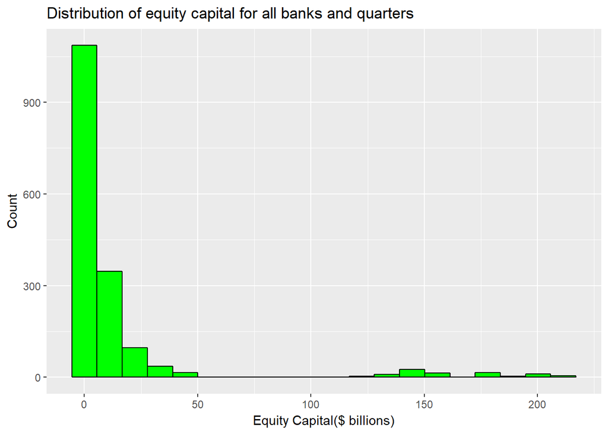

```r
ggplot(data = mergedBanks, aes(mergedBanks$Total.Equity.Capital2))+
  geom_histogram(bins = 20,col="black",fill="green")+
  labs(title = "Distribution of equity capital for all banks and quarters")+
  labs(x="Equity Capital($ billions)",y="Count")
```

Explore distribution of complaint count

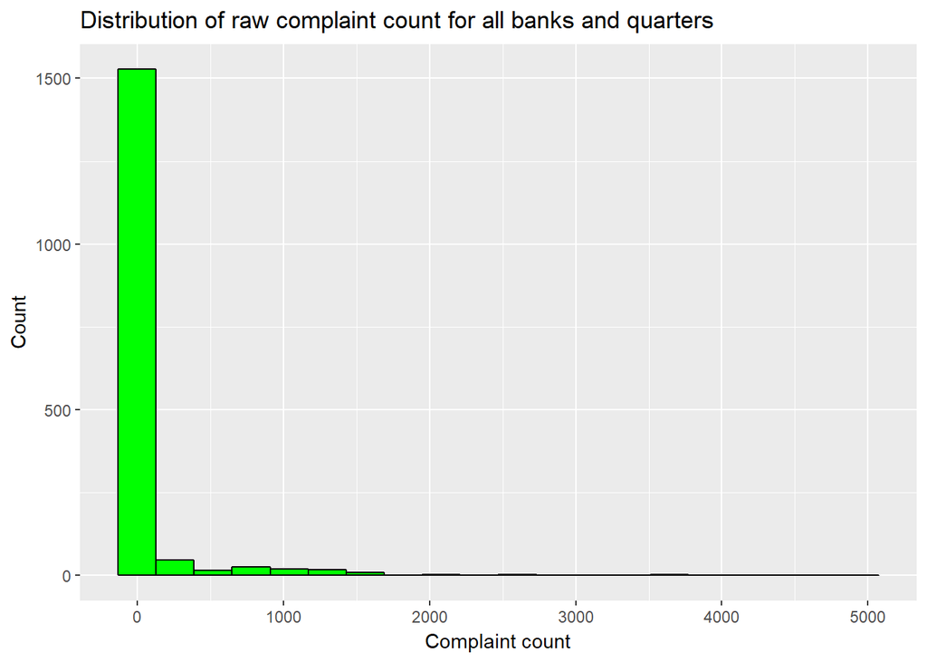

```r
ggplot(data = mergedBanks, aes(mergedBanks$complaintCount))+
  geom_histogram(bins = 20,col="black",fill="green")+
  labs(title = "Distribution of raw complaint count for all banks and quarters")+
  labs(x="Complaint count",y="Count")
```

Get the AVERAGE complaint counts and equity capital per bank

```r
MeanCompCntAndEqCapPerBank <- mergedBanks %>%
                                group_by(Company) %>%
                                summarise(MeanEquityCapital2=mean(Total.Equity.Capital2,na.rm=TRUE),
                                MeanEquityCapital=mean(Total.Equity.Capital,na.rm=TRUE),
                                MeanComplaintCount=mean(complaintCount,na.rm=TRUE))

write.csv(MeanCompCntAndEqCapPerBank, file="MeanCompCntAndEqCapPerBank.csv")
summary(MeanCompCntAndEqCapPerBank$MeanComplaintCount)
```

```
##      Min.   1st Qu.    Median      Mean   3rd Qu.      Max.
##    0.0454    0.9318    3.0000   70.8200   10.0200 1810.0000
```

Find relationship between equity capital per quarter and mean complaint count per quarter

```r
MortgageModel1 <- lm(mergedBanks$complaintCount ~ mergedBanks$Total.Equity.Capital2)
summary(MortgageModel1)
```

```
##
## Call:
## lm(formula = mergedBanks$complaintCount ~ mergedBanks$Total.Equity.Capital2)
##
## Residuals:
##    Min     1Q Median     3Q    Max
## -936.1  -25.2    2.3    9.2 3753.1
##
## Coefficients:
##                                   Estimate Std. Error t value Pr(>|t|)
## (Intercept)                       -17.3815     5.5011   -3.16  0.00161 **
## mergedBanks$Total.Equity.Capital2   6.7247     0.1396   48.16  < 2e-16 ***
## ---
## Signif. codes:  0 '***' 0.001 '**' 0.01 '*' 0.05 '.' 0.1 ' ' 1
##
## Residual standard error: 208.5 on 1667 degrees of freedom
## Multiple R-squared:  0.5818, Adjusted R-squared:  0.5815
## F-statistic:  2319 on 1 and 1667 DF,  p-value: < 2.2e-16
```

```r
cor(mergedBanks$complaintCount,mergedBanks$Total.Equity.Capital2)
```

```
## [1] 0.7627398
```

There is a strong, positive, linear relationship between quarterly equity capital and average complaints per quarter

Normalize complaint counts to remove effect of bank size (as measured by equity capital) on counts.

```r
mergedBanks$adjComplaintCount <- (mergedBanks$complaintCount-MortgageModel1$coefficients[1])/
                                mergedBanks$Total.Equity.Capital2

summary(mergedBanks$adjComplaintCount)
```

```
##     Min.  1st Qu.   Median     Mean  3rd Qu.     Max.
##   0.5801   3.8180   7.5160  10.3300  11.9700 118.0000
```

```r
write.csv(mergedBanks,file="mergedBanks.csv")
```

The correlation between adjusted complaint count and total equity capital is -0.1217716 Looks like we’ve removed the correlation between complaint count and equity capital

```r
MortgageModel3 <- lm(mergedBanks$adjComplaintCount~mergedBanks$Total.Equity.Capital2)
summary(MortgageModel3)
```

```
##
## Call:
## lm(formula = mergedBanks$adjComplaintCount ~ mergedBanks$Total.Equity.Capital2)
##
## Residuals:
##     Min      1Q  Median      3Q     Max
##  -9.251  -6.611  -2.760   1.574 107.101
##
## Coefficients:
##                                   Estimate Std. Error t value Pr(>|t|)
## (Intercept)                       10.91115    0.31160  35.016  < 2e-16 ***
## mergedBanks$Total.Equity.Capital2 -0.03962    0.00791  -5.009 6.05e-07 ***
## ---
## Signif. codes:  0 '***' 0.001 '**' 0.01 '*' 0.05 '.' 0.1 ' ' 1
##
## Residual standard error: 11.81 on 1667 degrees of freedom
## Multiple R-squared:  0.01483,    Adjusted R-squared:  0.01424
## F-statistic: 25.09 on 1 and 1667 DF,  p-value: 6.049e-07
```

R^2 is practically zero. So hardly any variation in adjusted complaint count is due to the linear relationship between adjusted complaint count and equity capital. between quarterly equity capital and quarterly average complaint counts.

Check distribution of adjusted complaint count for ALL banks combined

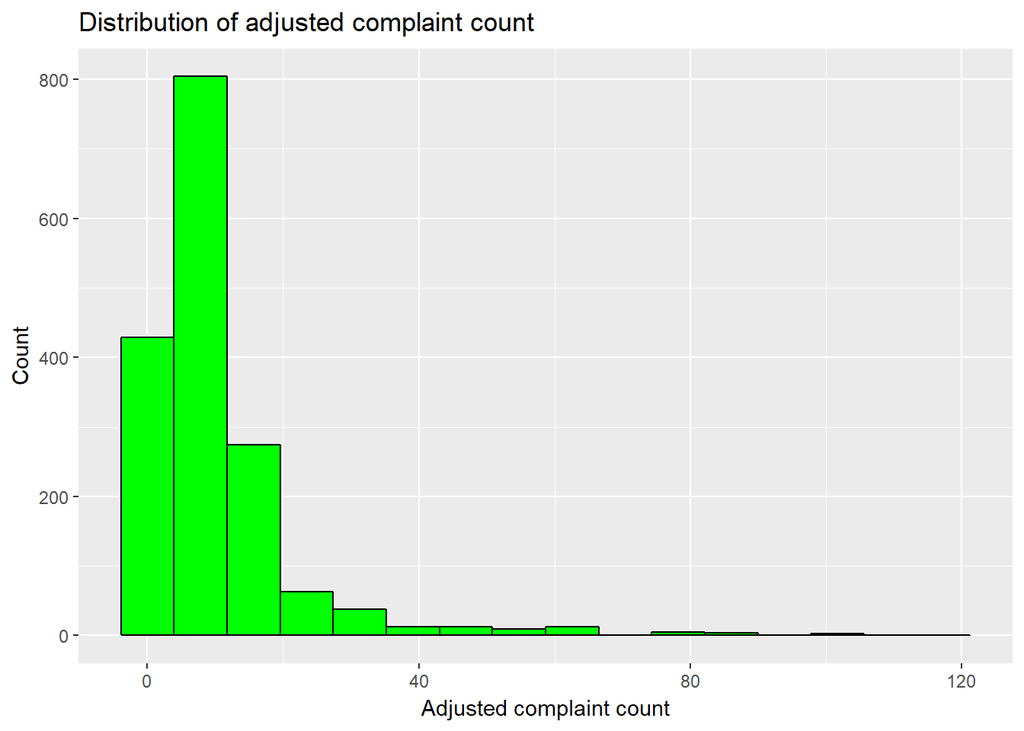

```r
ggplot(data = mergedBanks, aes(mergedBanks$adjComplaintCount))+
  geom_histogram(bins = 16,col="black",fill="green")+
  labs(title = "Distribution of adjusted complaint count")+
  labs(x="Adjusted complaint count",y="Count")
```

Compute average equity capital (taken over all quarters) for each bank

```r
mergedBanks %>%
  group_by(Company) %>%
  summarise(meanEqCap=mean(Total.Equity.Capital2))->MeanEqCapitalByBank
write.csv(MeanEqCapitalByBank,file="MeanEqCapitalByBank.csv")
```

Now find distributions of adjusted complaint counts for each bank separately, so we can see if the distributions look like Poisson.

(For some reason, ggplot doesn’t work in the loop below. )

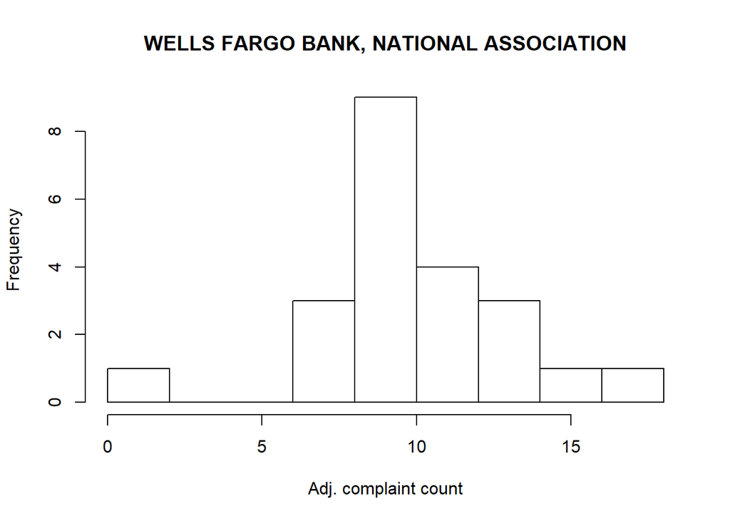

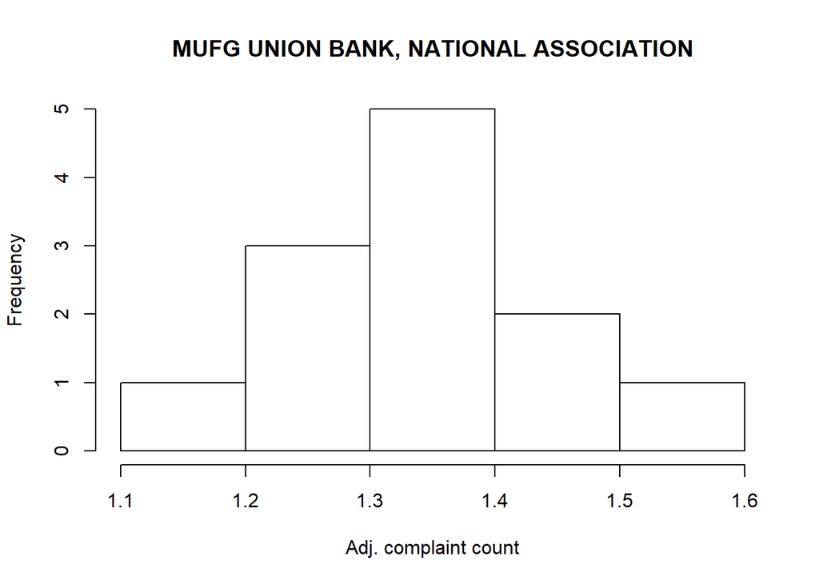

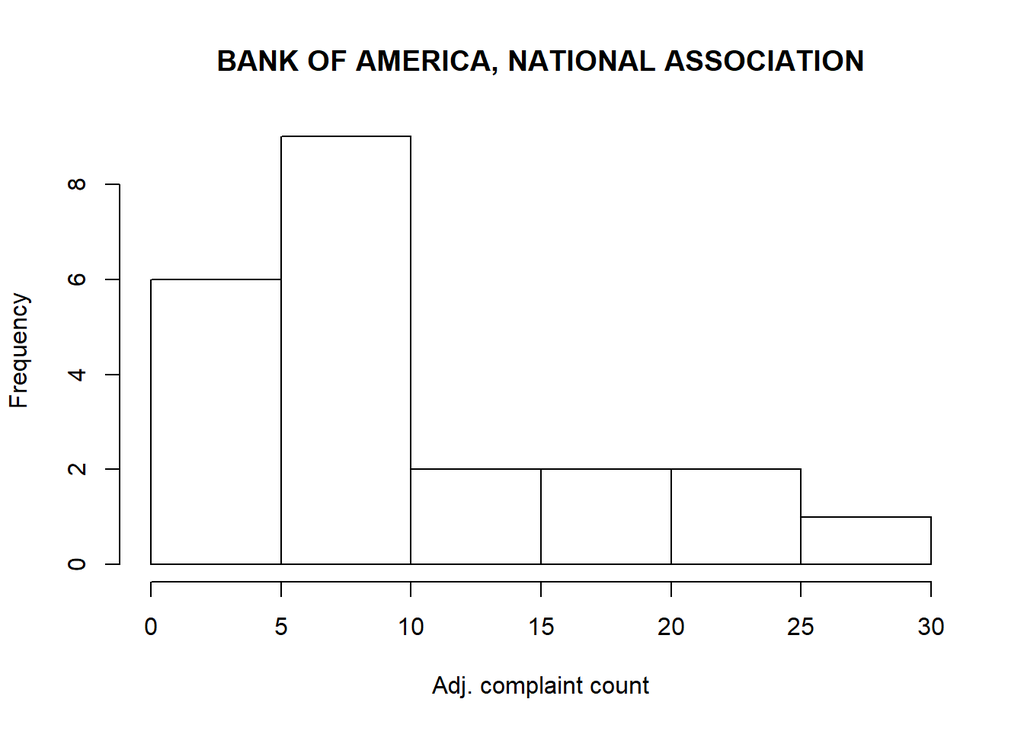

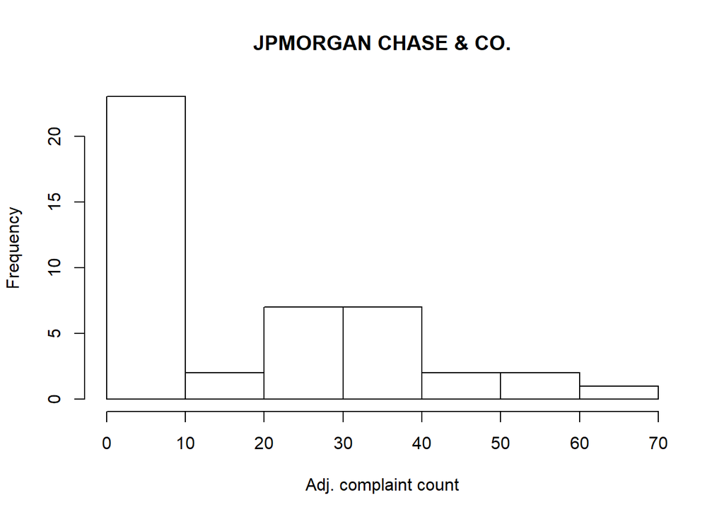

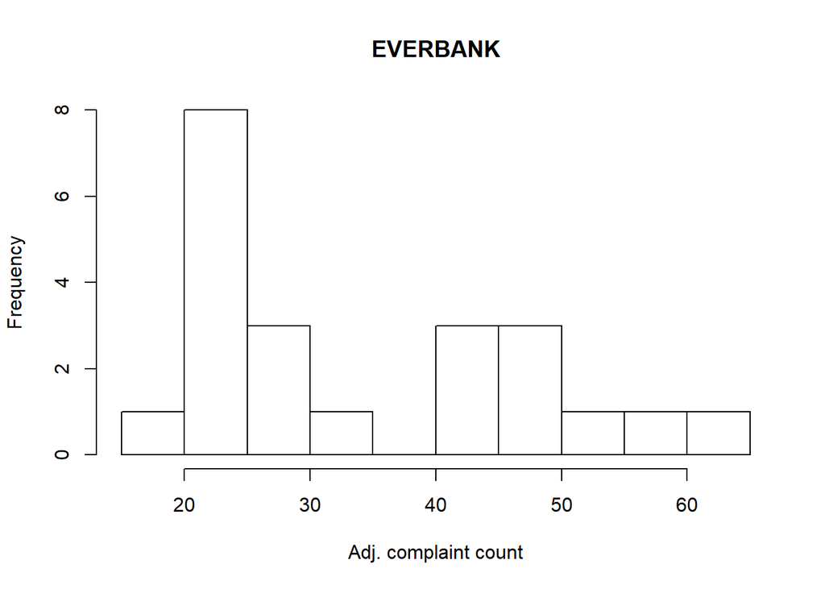

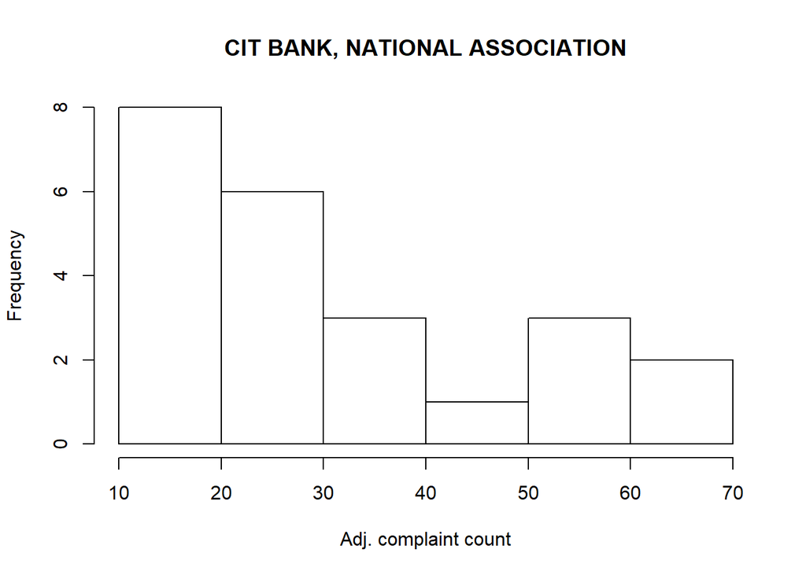

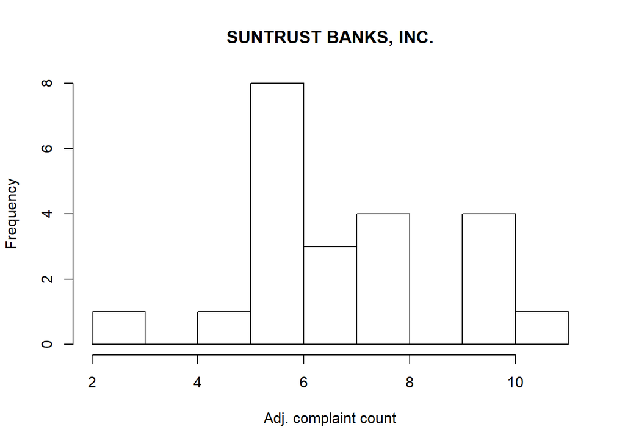

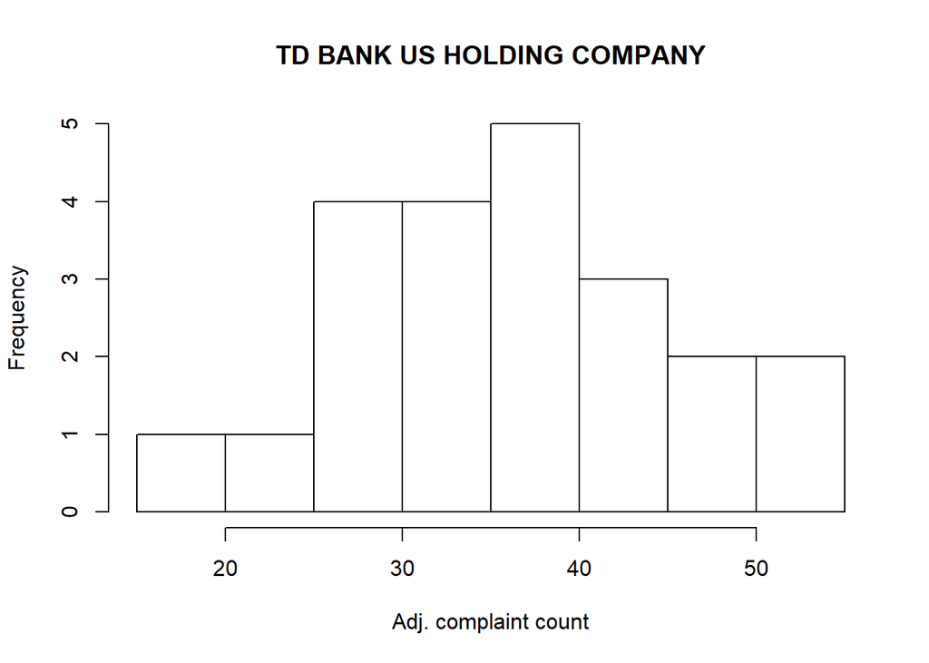

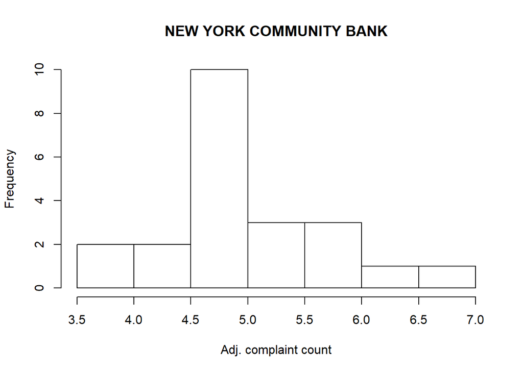

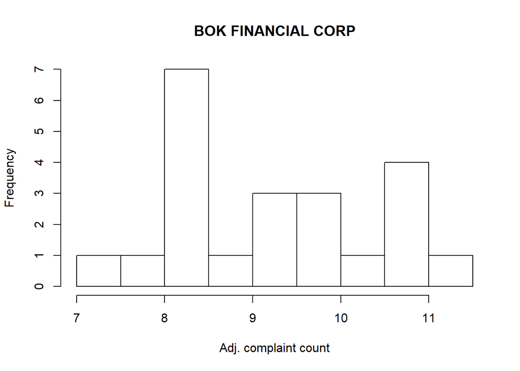

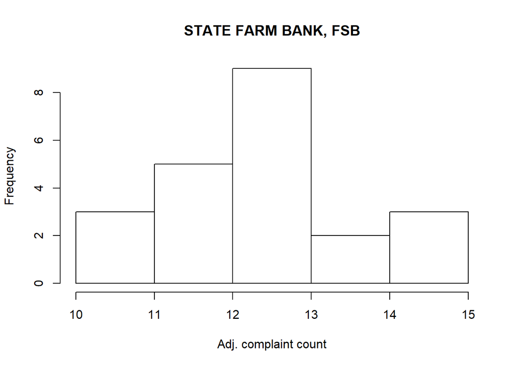

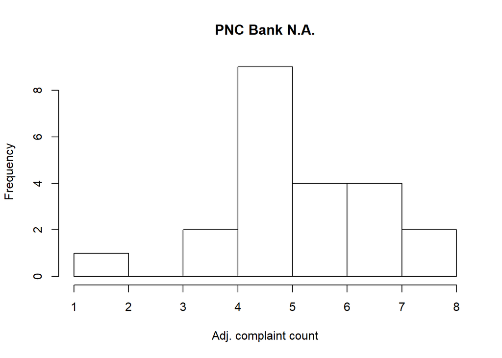

[63 more figures not shown]

```r
bankNames <- unique(mergedBanks$Company)
plot.new()

for (bankName in bankNames){
  hist(mergedBanks[mergedBanks$Company==bankName,]$adjComplaintCount,
       main=bankName,xlab="Adj. complaint count")
}
```

```r
#for (bankName in bankNames){
#  ggplot(data = mergedBanks[mergedBanks$Company == bankName,],
#  aes(mergedBanks[mergedBanks$Company == bankName,]$adjComplaintCount))+
#  geom_histogram(bins = 20,col="black",fill="green")+
#  labs(title = paste("Distribution of adjusted complaint count for  ",bankName))+
#  labs(x="Adjusted complaint count", y="Count")
#}
```

For some of the banks, the distributions of adjusted quarterly claim counts look Poisson. For other banks, the distributions look nothing like Poisson distributions. The latter observation could be due to insufficient data. We could try to remedy this by collecting the past 10 years of quarterly data instead of just the past 5 years; but this would only work if the parameter (lambda) for each bank remained constant over the past 10 years. This does not seem like a reasonable assumption.

Here we attempt to perform the chi-square goodness of fit test to see if the quarterly adjusted complaint counts (taken for each bank separately) have a Poisson distribution. In case of count data we can use goodfit() included in vcd package. Unfortunately, the “vcd” package seems to be missing.

Load numbers of employees.

```r
RankedBanksByNumEmpls_12_31_11 <- read.csv('RankedBanksByNumEmpls 12-31-11.csv',stringsAsFactors=FALSE)
RankedBanksByNumEmpls_3_31_12 <- read.csv('RankedBanksByNumEmpls 3-31-12.csv',stringsAsFactors=FALSE)
RankedBanksByNumEmpls_6_30_12 <- read.csv('RankedBanksByNumEmpls 6-30-12.csv',stringsAsFactors=FALSE)
RankedBanksByNumEmpls_9_30_12 <- read.csv('RankedBanksByNumEmpls 9-30-12.csv',stringsAsFactors=FALSE)
RankedBanksByNumEmpls_12_31_12 <- read.csv('RankedBanksByNumEmpls 12-31-12.csv',stringsAsFactors=FALSE)
RankedBanksByNumEmpls_3_31_13 <- read.csv('RankedBanksByNumEmpls 3-31-13.csv',stringsAsFactors=FALSE)
RankedBanksByNumEmpls_6_30_13 <- read.csv('RankedBanksByNumEmpls 6-30-13.csv',stringsAsFactors=FALSE)
RankedBanksByNumEmpls_9_30_13 <- read.csv('RankedBanksByNumEmpls 9-30-13.csv',stringsAsFactors=FALSE)
RankedBanksByNumEmpls_12_31_13 <- read.csv('RankedBanksByNumEmpls 12-31-13.csv',stringsAsFactors=FALSE)
RankedBanksByNumEmpls_3_31_14 <- read.csv('RankedBanksByNumEmpls 3-31-14.csv',stringsAsFactors=FALSE)
RankedBanksByNumEmpls_6_30_14 <- read.csv('RankedBanksByNumEmpls 6-30-14.csv',stringsAsFactors=FALSE)
RankedBanksByNumEmpls_9_30_14 <- read.csv('RankedBanksByNumEmpls 9-30-14.csv',stringsAsFactors=FALSE)
RankedBanksByNumEmpls_12_31_14 <- read.csv('RankedBanksByNumEmpls 12-31-14.csv',stringsAsFactors=FALSE)
RankedBanksByNumEmpls_3_31_15 <- read.csv('RankedBanksByNumEmpls 3-31-15.csv',stringsAsFactors=FALSE)
RankedBanksByNumEmpls_6_30_15 <- read.csv('RankedBanksByNumEmpls 6-30-15.csv',stringsAsFactors=FALSE)
RankedBanksByNumEmpls_9_30_15 <- read.csv('RankedBanksByNumEmpls 9-30-15.csv',stringsAsFactors=FALSE)
RankedBanksByNumEmpls_12_31_15 <- read.csv('RankedBanksByNumEmpls 12-31-15.csv',stringsAsFactors=FALSE)
RankedBanksByNumEmpls_3_31_16 <- read.csv('RankedBanksByNumEmpls 3-31-16.csv',stringsAsFactors=FALSE)
RankedBanksByNumEmpls_6_30_16 <- read.csv('RankedBanksByNumEmpls 6-30-16.csv',stringsAsFactors=FALSE)
RankedBanksByNumEmpls_9_30_16 <- read.csv('RankedBanksByNumEmpls 9-30-16.csv',stringsAsFactors=FALSE)
RankedBanksByNumEmpls_12_31_16 <- read.csv('RankedBanksByNumEmpls 12-31-16.csv',stringsAsFactors=FALSE)
RankedBanksByNumEmpls_3_31_17 <- read.csv('RankedBanksByNumEmpls 3-31-17.csv',stringsAsFactors=FALSE)
```

Stack the ranked banks into one set

```r
all_ranked_banksByNumEmpls  <-  rbind(RankedBanksByNumEmpls_12_31_11,
                          RankedBanksByNumEmpls_3_31_12,
                          RankedBanksByNumEmpls_6_30_12,
                          RankedBanksByNumEmpls_9_30_12,
                          RankedBanksByNumEmpls_12_31_12,
                          RankedBanksByNumEmpls_3_31_13,
                          RankedBanksByNumEmpls_6_30_13,
                          RankedBanksByNumEmpls_9_30_13,
                          RankedBanksByNumEmpls_12_31_13,
                          RankedBanksByNumEmpls_3_31_14,
                          RankedBanksByNumEmpls_6_30_14,
                          RankedBanksByNumEmpls_9_30_14,
                          RankedBanksByNumEmpls_12_31_14,
                          RankedBanksByNumEmpls_3_31_15,
                          RankedBanksByNumEmpls_6_30_15,
                          RankedBanksByNumEmpls_9_30_15,
                          RankedBanksByNumEmpls_12_31_15,
                          RankedBanksByNumEmpls_3_31_16,
                          RankedBanksByNumEmpls_6_30_16,
                          RankedBanksByNumEmpls_9_30_16,
                          RankedBanksByNumEmpls_12_31_16,
                          RankedBanksByNumEmpls_3_31_17)
```

Get year and quarter from the dates

```r
all_ranked_banksByNumEmpls$quarterYear <- paste(quarters(as.Date(all_ranked_banksByNumEmpls$Date,
                                              format="%m/%d/%Y")),
                                              substr(all_ranked_banksByNumEmpls$Date,
                                              nchar(all_ranked_banksByNumEmpls$Date)-3,
                                              nchar(all_ranked_banksByNumEmpls$Date)),sep=" ")

str(all_ranked_banksByNumEmpls)
```

```
## 'data.frame':    146811 obs. of  5 variables:
##  $ Rank               : int  1 2 3 4 5 6 7 8 9 10 ...
##  $ Date               : chr  "12/31/2011" "12/31/2011" "12/31/2011" "12/31/2011" ...
##  $ Number.of.Employees: chr  "225,886" "200,884" "199,292" "182,060" ...
##  $ Bank.Name          : chr  "Wells Fargo Bank" "JPMorgan Chase Bank" "Citibank" "Bank of America" ...
##  $ quarterYear        : chr  "Q4 2011" "Q4 2011" "Q4 2011" "Q4 2011" ...
```

Get rid of the commas in employee counts and convert the counts into integers.

```r
all_ranked_banksByNumEmpls$Number.of.Employees <-
  as.integer(gsub(",","",all_ranked_banksByNumEmpls$Number.of.Employees))

summary(all_ranked_banksByNumEmpls$Number.of.Employees)
```

```
##     Min.  1st Qu.   Median     Mean  3rd Qu.     Max.     NA's
##      0.0     20.0     41.0    312.3     91.0 239800.0     1084
```

Employee counts are very skewed to the right. And why would any of the counts be zero?

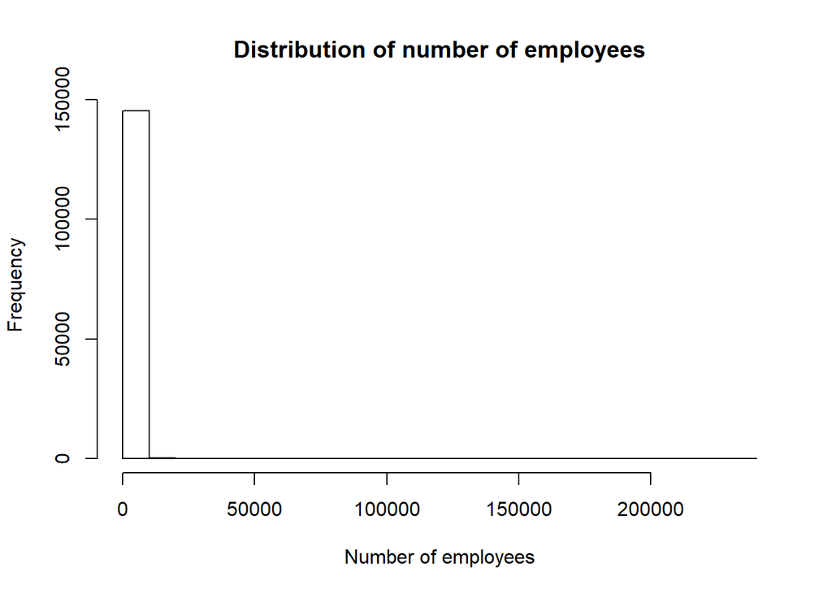

```r
hist(all_ranked_banksByNumEmpls$Number.of.Employees,
     main="Distribution of number of employees",
     xlab="Number of employees")
```

Merge onto complaint count/equity capital set

Keep only the employee count records where the bank is in the top 100 by equity capital.

```r
bankNumEmpls_top100 <- all_ranked_banksByNumEmpls[all_ranked_banksByNumEmpls$Bank.Name %in%
                                        unique_banks_from_ranked_banks_top100,
                                        c("Number.of.Employees","Bank.Name","quarterYear","Rank")]
```

There are 140 banks in the banks from the employee number data

Make sure the banks ranked by number of employees have just one rank per quarter

```r
numRanks2 <- bankNumEmpls_top100 %>%
  group_by(quarterYear,Bank.Name) %>%
  summarise(numranks=n_distinct(Rank))
summary(numRanks2$numranks)
```

```
##    Min. 1st Qu.  Median    Mean 3rd Qu.    Max.
##   1.000   1.000   1.000   1.385   1.000  20.000
```

Double-checking what I did above

```r
numCounts2 <- bankNumEmpls_top100 %>%
  group_by(quarterYear,Bank.Name) %>%
  summarise(numcounts=n_distinct(Number.of.Employees))
summary(numCounts2$numcounts)
```

```
##    Min. 1st Qu.  Median    Mean 3rd Qu.    Max.
##   1.000   1.000   1.000   1.385   1.000  20.000
```

Merge employee counts onto rest of bank data

```r
mergedBanks2 <- inner_join(mergedBanks,subset(bankNumEmpls_top100,
                        select=c("Number.of.Employees","Bank.Name","quarterYear"),
                        by=c("Bank.Name","quarterYear")))
summary(mergedBanks2$Number.of.Employees)
```

```
##    Min. 1st Qu.  Median    Mean 3rd Qu.    Max.
##       0      98    1403    8706    4346  239800
```

There are 0 missings

It seems that the normalized number of employees has little correlation with normalized complaint counts. Could this mean that banks have more employees than they need? This seems plausible due to the growth of online banking. Maybe banks can cut down on the number of tellers?

Let’s look at return on equity (ROE). My idea is that a bank with high profitability (as measured by ROE) might be sacrificing customer service in order to do so, and possibly even be more likely to engage in unethical behavior (which would, of course, cause consumer complaints).

Load return on equity

```r
RankedBanksByROE_12_31_11 <-   read.csv('RankedBanksByROE 12-31-11.csv', stringsAsFactors = FALSE)
RankedBanksByROE_3_31_12 <- read.csv('RankedBanksByROE 3-31-12.csv', stringsAsFactors = FALSE)
RankedBanksByROE_6_30_12 <- read.csv('RankedBanksByROE 6-30-12.csv', stringsAsFactors = FALSE)
RankedBanksByROE_9_30_12 <- read.csv('RankedBanksByROE 9-30-12.csv', stringsAsFactors = FALSE)
RankedBanksByROE_12_31_12 <- read.csv('RankedBanksByROE 12-31-12.csv', stringsAsFactors = FALSE)
RankedBanksByROE_3_31_13 <- read.csv('RankedBanksByROE 3-31-13.csv', stringsAsFactors = FALSE)
RankedBanksByROE_6_30_13 <- read.csv('RankedBanksByROE 6-30-13.csv', stringsAsFactors = FALSE)
RankedBanksByROE_9_30_13 <- read.csv('RankedBanksByROE 9-30-13.csv', stringsAsFactors = FALSE)
RankedBanksByROE_12_31_13 <- read.csv('RankedBanksByROE 12-31-13.csv', stringsAsFactors = FALSE)
RankedBanksByROE_3_31_14 <- read.csv('RankedBanksByROE 3-31-14.csv', stringsAsFactors = FALSE)
RankedBanksByROE_6_30_14 <- read.csv('RankedBanksByROE 6-30-14.csv', stringsAsFactors = FALSE)
RankedBanksByROE_9_30_14 <- read.csv('RankedBanksByROE 9-30-14.csv', stringsAsFactors = FALSE)
RankedBanksByROE_12_31_14 <- read.csv('RankedBanksByROE 12-31-14.csv', stringsAsFactors = FALSE)
RankedBanksByROE_3_31_15 <- read.csv('RankedBanksByROE 3-31-15.csv', stringsAsFactors = FALSE)
RankedBanksByROE_6_30_15 <- read.csv('RankedBanksByROE 6-30-15.csv', stringsAsFactors = FALSE)
RankedBanksByROE_9_30_15 <- read.csv('RankedBanksByROE 9-30-15.csv', stringsAsFactors = FALSE)
RankedBanksByROE_12_31_15 <- read.csv('RankedBanksByROE 12-31-15.csv', stringsAsFactors = FALSE)
RankedBanksByROE_3_31_16 <- read.csv('RankedBanksByROE 3-31-16.csv', stringsAsFactors = FALSE)
RankedBanksByROE_6_30_16 <- read.csv('RankedBanksByROE 6-30-16.csv', stringsAsFactors = FALSE)
RankedBanksByROE_9_30_16 <- read.csv('RankedBanksByROE 9-30-16.csv', stringsAsFactors = FALSE)
RankedBanksByROE_12_31_16 <- read.csv('RankedBanksByROE 12-31-16.csv', stringsAsFactors = FALSE)
RankedBanksByROE_3_31_17 <- read.csv('RankedBanksByROE 3-31-17.csv', stringsAsFactors = FALSE)

RankedBanksByROE_3_31_12 <- subset(RankedBanksByROE_3_31_12, select = -X)

AllRankedBanksByROE  <-  rbind(RankedBanksByROE_12_31_11,
                            RankedBanksByROE_3_31_12,
                            RankedBanksByROE_6_30_12,
                            RankedBanksByROE_9_30_12,
                            RankedBanksByROE_12_31_12,
                            RankedBanksByROE_3_31_13,
                            RankedBanksByROE_6_30_13,
                            RankedBanksByROE_9_30_13,
                            RankedBanksByROE_12_31_13,
                            RankedBanksByROE_3_31_14,
                            RankedBanksByROE_6_30_14,
                            RankedBanksByROE_9_30_14,
                            RankedBanksByROE_12_31_14,
                            RankedBanksByROE_3_31_15,
                            RankedBanksByROE_6_30_15,
                            RankedBanksByROE_9_30_15,
                            RankedBanksByROE_12_31_15,
                            RankedBanksByROE_3_31_16,
                            RankedBanksByROE_6_30_16,
                            RankedBanksByROE_9_30_16,
                            RankedBanksByROE_12_31_16,
                            RankedBanksByROE_3_31_17)

AllRankedBanksByROE$quarterYear <- paste(quarters(as.Date(AllRankedBanksByROE$Date, format="%m/%d/%Y")),
                                      substr(AllRankedBanksByROE$Date, nchar(AllRankedBanksByROE$Date)-3,
                                             nchar(AllRankedBanksByROE$Date)), sep=" ")
AllRankedBanksByROE$Quarterly.Return.on.Equity <-
     as.numeric(gsub("%","",AllRankedBanksByROE$Quarterly.Return.on.Equity))/100
str(AllRankedBanksByROE)
```

[output not shown]

Keep only the ROE records where the bank is in the top 100 by equity capital.

```r
bankROE_top100 <- AllRankedBanksByROE[AllRankedBanksByROE$Bank.Name %in%
                                    unique_banks_from_ranked_banks_top100,
                                    c("Quarterly.Return.on.Equity","Bank.Name","quarterYear")]
```

There are 140 banks in the ROE set

Make sure the banks ranked by ROE have just one value of ROE per quarter

```r
numRanks3 <- bankROE_top100 %>%
  group_by(quarterYear,Bank.Name) %>%
  summarise(numranks=n_distinct(Quarterly.Return.on.Equity))
summary(numRanks3$numranks)
```

```
##    Min. 1st Qu.  Median    Mean 3rd Qu.    Max.
##   1.000   1.000   1.000   1.309   1.000  16.000
```

Merge bank ROEs onto rest of bank data

```r
mergedBanks3 <- inner_join(mergedBanks2,subset(bankROE_top100,
                select=c("Quarterly.Return.on.Equity","Bank.Name","quarterYear"),
                by=c("Bank.Name","quarterYear")))
str(mergedBanks3)
```

```
## 'data.frame':    1160566 obs. of  9 variables:
##  $ Company                   : chr  "WELLS FARGO BANK, NATIONAL ASSOCIATION" "WELLS FARGO BANK, NATIONAL ASSOCIATION" "WELLS FARGO BANK, NATIONAL ASSOCIATION" "WELLS FARGO BANK, NATIONAL ASSOCIATION" ...
##  $ quarterYear               : chr  "Q1 2012" "Q1 2012" "Q1 2012" "Q1 2012" ...
##  $ complaintCount            : num  1248 1248 1248 1248 1248 ...
##  $ Total.Equity.Capital      : num  1.26e+11 1.26e+11 1.26e+11 1.26e+11 1.26e+11 ...
##  $ Total.Equity.Capital2     : num  126 126 126 126 126 ...
##  $ adjComplaintCount         : num  10.1 10.1 10.1 10.1 10.1 ...
##  $ Number.of.Employees       : int  225752 204717 194818 181328 60744 53998 32647 29062 27602 27602 ...
##  $ Bank.Name                 : chr  "Wells Fargo Bank" "JPMorgan Chase Bank" "Citibank" "Bank of America" ...
##  $ Quarterly.Return.on.Equity: num  0.11 0.09 0.07 0.08 0.16 0.06 0.04 0.1 0.11 0.09 ...
```

```r
summary(mergedBanks3$Quarterly.Return.on.Equity)
```

```
##     Min.  1st Qu.   Median     Mean  3rd Qu.     Max.
## -1.93000  0.05000  0.08000  0.08914  0.13000  3.39000
```

```r
sum(is.na(mergedBanks3$Number.of.Employees))
```

```
## [1] 0
```

The correlation between adjusted complaint count and quarterly return on equity is 0.0046014

We next hypothesize that a bank’s total amount past due is a driver of customer complaints. Our reasoning is that banks would send notices to delinquent borrowers, which could trigger complaints (e.g., of harassment). Also, a borrower who is late might complain that the bank did not make the terms of the loan clear. Finally, if a bank has a large amount of past due loans, then its clientele just might be irresponsible in general, and hence more likely to blame the bank for its actions.

Load banks ranked by total amount past due 30-89 days

```r
RankedByPastDue30_89Days_12_31_11 <- read.csv('RankedByPastDue30_89Days 12-31-11.csv', stringsAsFactors = FALSE)
RankedByPastDue30_89Days_3_31_12 <- read.csv('RankedByPastDue30_89Days 3-31-12.csv', stringsAsFactors = FALSE)
RankedByPastDue30_89Days_6_30_12 <- read.csv('RankedByPastDue30_89Days 6-30-12.csv', stringsAsFactors = FALSE)
RankedByPastDue30_89Days_9_30_12 <- read.csv('RankedByPastDue30_89Days 9-30-12.csv', stringsAsFactors = FALSE)
RankedByPastDue30_89Days_12_31_12 <- read.csv('RankedByPastDue30_89Days 12-31-12.csv', stringsAsFactors = FALSE)
RankedByPastDue30_89Days_3_31_13 <- read.csv('RankedByPastDue30_89Days 3-31-13.csv', stringsAsFactors = FALSE)
RankedByPastDue30_89Days_6_30_13 <- read.csv('RankedByPastDue30_89Days 6-30-13.csv', stringsAsFactors = FALSE)
RankedByPastDue30_89Days_9_30_13 <- read.csv('RankedByPastDue30_89Days 9-30-13.csv', stringsAsFactors = FALSE)
RankedByPastDue30_89Days_12_31_13 <- read.csv('RankedByPastDue30_89Days 12-31-13.csv', stringsAsFactors = FALSE)
RankedByPastDue30_89Days_3_31_14 <- read.csv('RankedByPastDue30_89Days 3-31-14.csv', stringsAsFactors = FALSE)
RankedByPastDue30_89Days_6_30_14 <- read.csv('RankedByPastDue30_89Days 6-30-14.csv', stringsAsFactors = FALSE)
RankedByPastDue30_89Days_9_30_14 <- read.csv('RankedByPastDue30_89Days 9-30-14.csv', stringsAsFactors = FALSE)
RankedByPastDue30_89Days_12_31_14 <- read.csv('RankedByPastDue30_89Days 12-31-14.csv', stringsAsFactors = FALSE)
RankedByPastDue30_89Days_3_31_15 <- read.csv('RankedByPastDue30_89Days 3-31-15.csv', stringsAsFactors = FALSE)
RankedByPastDue30_89Days_6_30_15 <- read.csv('RankedByPastDue30_89Days 6-30-15.csv', stringsAsFactors = FALSE)
RankedByPastDue30_89Days_9_30_15 <- read.csv('RankedByPastDue30_89Days 9-30-15.csv', stringsAsFactors = FALSE)
RankedByPastDue30_89Days_12_31_15 <- read.csv('RankedByPastDue30_89Days 12-31-15.csv', stringsAsFactors = FALSE)
RankedByPastDue30_89Days_3_31_16 <- read.csv('RankedByPastDue30_89Days 3-31-16.csv', stringsAsFactors = FALSE)
RankedByPastDue30_89Days_6_30_16 <- read.csv('RankedByPastDue30_89Days 6-30-16.csv', stringsAsFactors = FALSE)
RankedByPastDue30_89Days_9_30_16 <- read.csv('RankedByPastDue30_89Days 9-30-16.csv', stringsAsFactors = FALSE)
RankedByPastDue30_89Days_12_31_16 <- read.csv('RankedByPastDue30_89Days 12-31-16.csv', stringsAsFactors = FALSE)
RankedByPastDue30_89Days_3_31_17 <- read.csv('RankedByPastDue30_89Days 3-31-17.csv', stringsAsFactors = FALSE)

AllRankedBanksByPastDue30_89Days <- rbind(RankedByPastDue30_89Days_12_31_11,
RankedByPastDue30_89Days_3_31_12 ,
RankedByPastDue30_89Days_6_30_12,
RankedByPastDue30_89Days_9_30_12,
RankedByPastDue30_89Days_12_31_12,
RankedByPastDue30_89Days_3_31_13,
RankedByPastDue30_89Days_6_30_13,
RankedByPastDue30_89Days_9_30_13,
RankedByPastDue30_89Days_12_31_13,
RankedByPastDue30_89Days_3_31_14,
RankedByPastDue30_89Days_6_30_14,
RankedByPastDue30_89Days_9_30_14,
RankedByPastDue30_89Days_12_31_14,
RankedByPastDue30_89Days_3_31_15,
RankedByPastDue30_89Days_6_30_15,
RankedByPastDue30_89Days_9_30_15,
RankedByPastDue30_89Days_12_31_15,
RankedByPastDue30_89Days_3_31_16,
RankedByPastDue30_89Days_6_30_16,
RankedByPastDue30_89Days_9_30_16,
RankedByPastDue30_89Days_12_31_16,
RankedByPastDue30_89Days_3_31_17)

AllRankedBanksByPastDue30_89Days$quarterYear <-
  paste(quarters(as.Date(AllRankedBanksByPastDue30_89Days$Date, format="%m/%d/%Y")),
        substr(AllRankedBanksByPastDue30_89Days$Date, nchar(AllRankedBanksByPastDue30_89Days$Date)-3,
                                                nchar(AllRankedBanksByPastDue30_89Days$Date)),
                                                sep=" ")

names(AllRankedBanksByPastDue30_89Days)[names(AllRankedBanksByPastDue30_89Days) ==
        'Secured.by.1.4.family.residential.properties..past.due.30...89.days'] <- 'AmtPastDue30_89Days'
```

We have to change amounts from strings to numbers

```r
AllRankedBanksByPastDue30_89Days$AmtPastDue30_89Days <-
    as.numeric(gsub("[$, ]","",AllRankedBanksByPastDue30_89Days$AmtPastDue30_89Days))
str(AllRankedBanksByPastDue30_89Days)
```

```
## 'data.frame':    148318 obs. of  5 variables:
##  $ Rank               : chr  "1" "2" "3" "4" ...
##  $ Date               : chr  "12/31/2011" "12/31/2011" "12/31/2011" "12/31/2011" ...
##  $ AmtPastDue30_89Days: num  1.02e+10 9.98e+09 5.54e+09 4.97e+09 1.31e+09 ...
##  $ Bank.Name          : chr  "Wells Fargo Bank" "Bank of America" "JPMorgan Chase Bank" "Citibank" ...
##  $ quarterYear        : chr  "Q4 2011" "Q4 2011" "Q4 2011" "Q4 2011" ...
```

```r
head(AllRankedBanksByPastDue30_89Days)
```

```
##   Rank       Date AmtPastDue30_89Days           Bank.Name quarterYear
## 1    1 12/31/2011         10187000000    Wells Fargo Bank     Q4 2011
## 2    2 12/31/2011          9982346000     Bank of America     Q4 2011
## 3    3 12/31/2011          5544000000 JPMorgan Chase Bank     Q4 2011
## 4    4 12/31/2011          4968000000            Citibank     Q4 2011
## 5    5 12/31/2011          1309646000           U.S. Bank     Q4 2011
## 6    6 12/31/2011          1102808000            PNC Bank     Q4 2011
```

Keep only the past due amount records where the bank is in the top 100 by equity capital.

```r
banksPastDue30_89Days_top100 <-
  AllRankedBanksByPastDue30_89Days[AllRankedBanksByPastDue30_89Days$Bank.Name %in%
                                   unique_banks_from_ranked_banks_top100,
                                   c("AmtPastDue30_89Days","Bank.Name","quarterYear")]
```

There are 140 banks in the past due data

Make sure the banks have just one past due value per quarter

```r
numRanks4 <- banksPastDue30_89Days_top100 %>%
  group_by(quarterYear,Bank.Name) %>%
  summarise(numranks=n_distinct(AmtPastDue30_89Days))
summary(numRanks4$numranks)
```

```
##    Min. 1st Qu.  Median    Mean 3rd Qu.    Max.
##   1.000   1.000   1.000   1.358   1.000  19.000
```

Merge amounts past due 30-89 days onto rest of bank data

```r
mergedBanks4 <- inner_join(mergedBanks3,subset(banksPastDue30_89Days_top100,
                              select=c("AmtPastDue30_89Days","Bank.Name","quarterYear"),
                                               by=c("Bank.Name","quarterYear")))
mergedBanks4$adjAmtPastDue30_89Days <- mergedBanks4$AmtPastDue30_89Days/mergedBanks4$Total.Equity.Capital
str(mergedBanks4)
```

```
## 'data.frame':    14213326 obs. of  11 variables:
##  $ Company                   : chr  "WELLS FARGO BANK, NATIONAL ASSOCIATION" "WELLS FARGO BANK, NATIONAL ASSOCIATION" "WELLS FARGO BANK, NATIONAL ASSOCIATION" "WELLS FARGO BANK, NATIONAL ASSOCIATION" ...
##  $ quarterYear               : chr  "Q1 2012" "Q1 2012" "Q1 2012" "Q1 2012" ...
##  $ complaintCount            : num  1248 1248 1248 1248 1248 ...
##  $ Total.Equity.Capital      : num  1.26e+11 1.26e+11 1.26e+11 1.26e+11 1.26e+11 ...
##  $ Total.Equity.Capital2     : num  126 126 126 126 126 ...
##  $ adjComplaintCount         : num  10.1 10.1 10.1 10.1 10.1 ...
##  $ Number.of.Employees       : int  225752 204717 194818 181328 60744 53998 32647 29062 27602 27602 ...
##  $ Bank.Name                 : chr  "Wells Fargo Bank" "JPMorgan Chase Bank" "Citibank" "Bank of America" ...
##  $ Quarterly.Return.on.Equity: num  0.11 0.09 0.07 0.08 0.16 0.06 0.04 0.1 0.11 0.11 ...
##  $ AmtPastDue30_89Days       : num  9.74e+09 4.96e+09 4.67e+09 7.98e+09 1.09e+09 ...
##  $ adjAmtPastDue30_89Days    : num  0.0774 0.03943 0.03712 0.06345 0.00863 ...
```

```r
summary(mergedBanks4$adjAmtPastDue30_89Days)
```

```
##     Min.  1st Qu.   Median     Mean  3rd Qu.     Max.
##  0.00000  0.00001  0.00010  0.00329  0.00049 52.85000
```

```r
cor(mergedBanks4$adjComplaintCount,mergedBanks4$adjAmtPastDue30_89Days)
```

```
## [1] 0.02367267
```

There are 0 missings

The correlation between adjusted complaint count and amount past due is 0.0236727

Load total deposits next?

Let’s think about the consumer side of problem. Can look at effects of zip code, issue, date,…

In our dashboard, we can allow the customer to select a bank and view its issue distribution.

Here’s the overall issue distribution: 17033, 5599, 111682, 76478, 5372, 8859 Maybe, instead of predicting complaint count, we should predict complaint count by issue? Could also include trends (e.g., is the number of complaints for zip2 33 increasing over time?)

The dashboard could also provide customer comments for the complaints

```r
consumer_complaints_mortgage$zip2 <- substr(consumer_complaints_mortgage$ZIP.code,1,2)

consumer_complaint_counts_byZIP  <-  consumer_complaints_mortgage %>%
  group_by(zip2) %>%
  summarise(complaintCount = n_distinct(Complaint.ID))

write.csv(consumer_complaint_counts_byZIP,file = "consumer_complaint_counts_byZIP.csv")
```